# scholar: Analyse citation data from Google Scholar

Guangchuang Yu, James Keirstead and Gregory Jefferis

2026-02-26

# Retrieving basic information

```r
## Define the id for Richard Feynman
id <- 'B7vSqZsAAAAJ'

## Get his profile
get_profile(id)
```

```
## $id
## [1] "B7vSqZsAAAAJ"
##
## $name
## [1] "Richard Feynman"
##
## $affiliation
## [1] "California Institute of Technology"
##
## $total_cites
## [1] 136093
##
## $h_index
## [1] 62
##
## $i10_index
## [1] 102
##
## $fields
## [1] "quantum mechanics"       "quantum electrodynamics"
##
## $homepage
## character(0)
##
## $coauthors
## [1] "Sort by citations" "Sort by year"      "Sort by title"
## [4] "About Scholar"     "Search help"
##
## $available
## [1] NA
##
## $not_available
## [1] NA
```

# Retrieving publications

`get_publications()` return a `data.frame` of publication records. It contains information of the publications, including *title*, *author list*, *page number*, *citation number*, *publication year*, *etc.*.

The `pubid` is the article ID used by Google Scholar and the identifier that is used to retrieve the citation history of a selected publication.

```r
## Get his publications (a large data frame)
p <- get_publications(id)
head(p, 3)
```

```
##                                    title
## 1 Quantum mechanics and path integration
## 2        The Feynman lectures on physics
## 3      Simulating physics with computers
##                                         author
## 1                         RP Feynman, AR Hibbs
## 2 RP Feynman, RB Leighton, M Sands, SB Treiman
## 3                                   RP Feynman
##                                        journal          number cites year
## 1                                  McGraw–Hill                 38731 1965
## 2                                Physics Today          17, 45 24051 1964
## 3 International journal of theoretical physics 21 (6), 467-488 15402 1982
##                                                                                  cid
## 1                     14769952204323476283,12549707430555464374,18041911941623786099
## 2 14769952204323476283,15649786516955137750,13112633961799421939,3669163321259408309
## 3                                                               15599256484525608168
##          pubid
## 1 hMod-77fHWUC
## 2 u-x6o8ySG0sC
## 3 d1gkVwhDpl0C
```

# Retrieving citation data

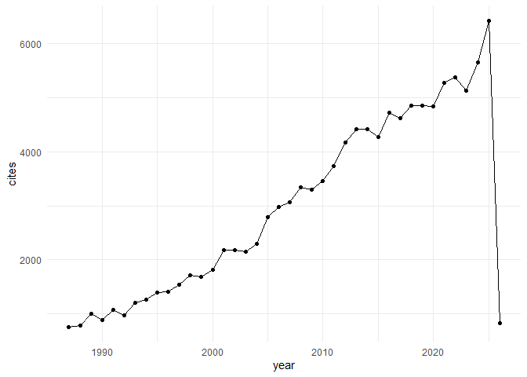

```r
## Get his citation history, i.e. citations to his work in a given year
ct <- get_citation_history(id)

## Plot citation trend
library(ggplot2)
ggplot(ct, aes(year, cites)) + geom_line() + geom_point()
```

Users can retrieve the citation history of a particular publication with `get_article_cite_history()`.

```r
## The following publication will be used to demonstrate article citation history
as.character(p$title[1])
```

```
## [1] "Quantum mechanics and path integration"
```

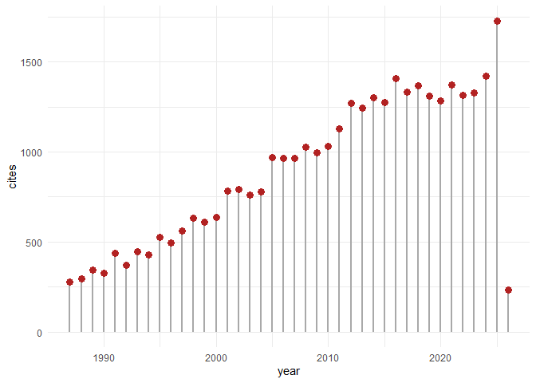

```r
## Get article citation history
ach <- get_article_cite_history(id, p$pubid[1])

## Plot citation trend
ggplot(ach, aes(year, cites)) +
    geom_segment(aes(xend = year, yend = 0), linewidth=1, color='darkgrey') +
    geom_point(size=3, color='firebrick')
```